# Part II - (Analysis for Ford GoBike Service)

## by (Maryam Abdullah)

## Investigation Overview

In this project, We aim to demonstrate the value and importance of data visualization techniques in the data analysis process. First, we use Python's NumPy, and pandas libraries to explore data then we use Matplotlib and Seaborn to visualize data. This project will take you to understand the user behavior toward the biking system, which will help you in your investment decision in the future regarding the biking sharing system.

## Dataset Overview

The data inculde information regarding approximately 183412 trip made in a bike-sharing system covering the San Francisco Bay area. Which they described with 16 features include duration, customer type, and gender, as well as additional variables such as member's year of birth, start and end station name, start and end station longitude, and latitude.

## (User type)

Since knowing the type of user in each business help to observe and understand its behavior, in this data for Gobike service the majority of user is a subscriber

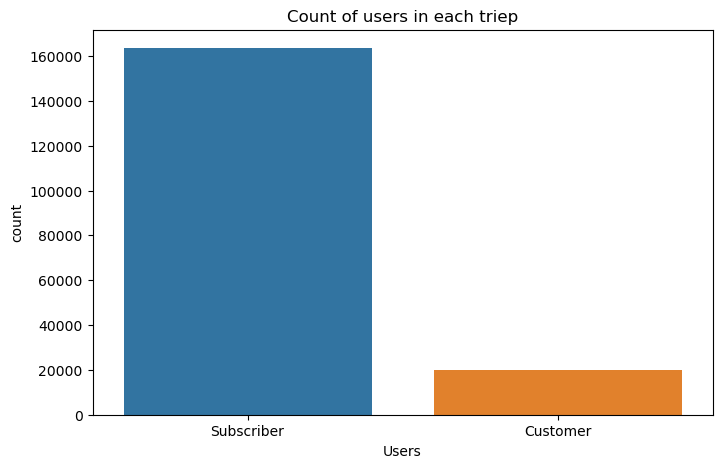

## (User Age)

The majority of users are subscribers and young, between the ages of 22-25 and 25-45. Consequently, it is a positive sign since they will be able to stay with this type of business and enjoy riding bikes if they are young.

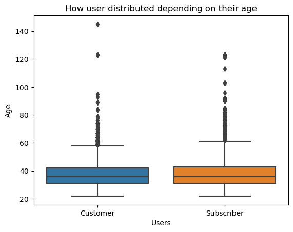

## (Duration usage over a week day)

As we see previously most of the users are young so they spend more minutes on each trip. But because they are mostly subscribed they spend less time over the week, on the other hand, they almost spend more than 20 minutes at weekend. Overall, If your main target is customers or subscribed you should provide more bikes at the stations during the weekend.

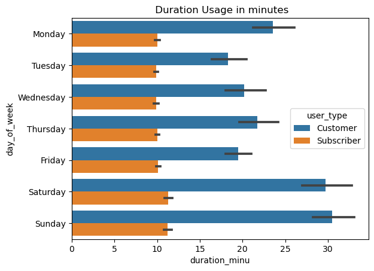

## ( Peak time for riding bikes )

Most of the customers and subscribers use bikes at the same time so this means there are high demands at 17 PM or 8 AM . For that you should plan to provide more at these hours.Also,customers may have more flexible time and use almost more after 12 PM

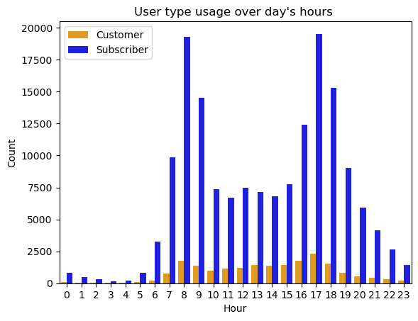